# Decision trees

# Party !

The package we will be using to perform decision trees is called **party**. In this package, the important function is called ctree to perform a **cart** analysis. **CART** stands for *Classification and Regression Test*. The package is capable of taking continuous variables and using them for classification.

```r
library("party")
```

The dataset we will testing our code is the same that we have used in the past. It is a dataset where alive status is the output variable, where 1 means dead and 0 means alive. The variables are measurements of breast tumors and some markers.

```r
data<-read.table("all.15k.patients.txt", header=T)
head(data)
```

|  | dateofbirth | maritalstatus | race | ageatdiagnosis | alivestatus | survivaltime | grade | nodesexam | nodespos | extent | nodalstatus | size | pgr | er |
| --- | --- | --- | --- | --- | --- | --- | --- | --- | --- | --- | --- | --- | --- | --- |
| pid00001 | 28/01/1932 | 5 | 2 | 61 | 0 | 110 | 3 | 32 | 3 | 10 | 6 | 60 | 2 | 2 |
| pid00002 | 07/05/1934 | 2 | 3 | 60 | 0 | 100 | 2 | 13 | 1 | 10 | 6 | 15 | 1 | 1 |
| pid00003 | 14/04/1921 | 5 | 3 | 76 | 0 | 70 | 3 | 8 | 0 | 10 | 0 | 8 | 1 | 1 |
| pid00004 | 08/11/1931 | 3 | 3 | 61 | 1 | 31 | 3 | 20 | 0 | 10 | 0 | 10 | 2 | 2 |
| pid00005 | 08/01/1922 | 2 | 3 | 74 | 1 | 47 | 2 | 16 | 8 | 10 | 6 | 15 | 2 | 1 |
| pid00006 | 03/12/1939 | 2 | 3 | 55 | 0 | 100 | 3 | 19 | 0 | 10 | 0 | 48 | 1 | 1 |

```r
data$alivestatus = as.factor(data$alivestatus)
data$grade = as.factor(data$grade)
data$nodespos = as.numeric(data$nodespos)
```

In order to create a decision tree model, the same syntax as what we used for regression can be used.

```r
Disease.fit<-ctree(formula=alivestatus ~ nodespos + grade + size, data=data)
```

As always, we will first test, using the same dataset as the training set, to see how well the model worked. This obvoiusly is not a fair assesment, but we expect this to give us the best predictions possible.

```r
results = predict(Disease.fit)
table(data$alivestatus, results)
```

```
   results
        0     1
  0 11678   567
  1  1941   814
```

We can also plot this decision tree

[figure not shown]

```r
plot(Disease.fit)
```

# AUC

To evaluate our models, letâs calculate the AUC. The default result of the predict function is the actual prediction of the state. However we can also ask for the probabilities of the calls, which will help us create the AUC curves.

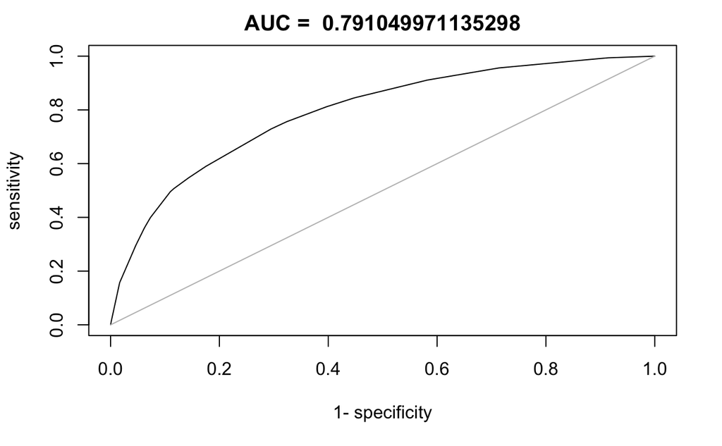

```r
resultsr = predict(Disease.fit, type="response")
resultsp = predict(Disease.fit, type="prob")
resultsp.df = t(as.data.frame(resultsp))
library(AUC)
roc_result = roc(resultsp.df[,2],data$alivestatus)
plot(roc_result, main=paste("AUC = ", auc(roc_result), sep=" "))
```

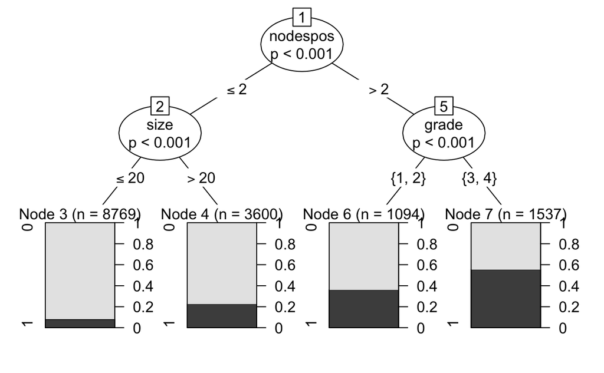

```r
Disease.fit2<-ctree(formula=alivestatus ~ nodespos + grade + size,
                   data=data,
                   controls = ctree_control(maxdepth = 2))
plot(Disease.fit2)
```

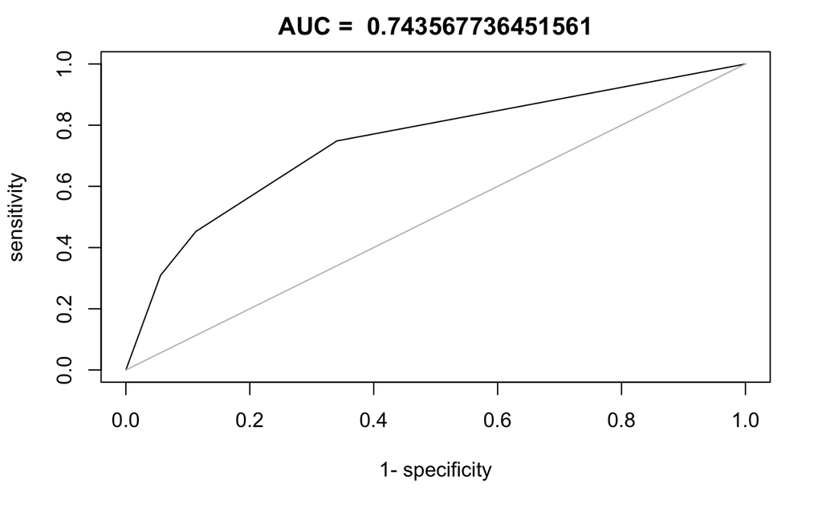

```r
results2r = predict(Disease.fit2, type="response")
results2p = predict(Disease.fit2, type="prob")
results2p.df = t(as.data.frame(results2p))
library(AUC)
roc_result2 = roc(results2p.df[,2],data$alivestatus)
plot(roc_result2, main=paste("AUC = ", auc(roc_result2), sep=" "))
```

# Leave Out test

As we have learned in class, it is not the best idea to use the same dataset to train and test the dataset. So for this example we will use the same leave out method as applied in the *Logistic Regression* section

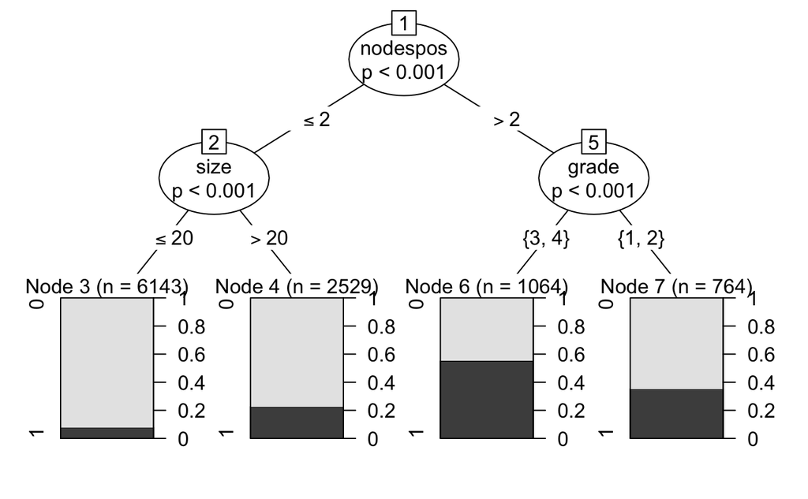

```r
split<-sample(nrow(data), floor(nrow(data) * 0.7))
split.train<-data[split,]
split.test<-data[-split,]
Disease.fit3<-ctree(formula=alivestatus ~ nodespos + grade + size,
                   data=split.train,
                   controls = ctree_control(maxdepth = 2))
plot(Disease.fit3)
```

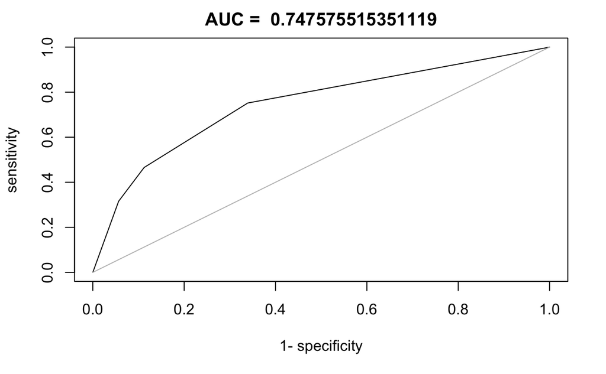

```r
results3r = predict(Disease.fit3,
                    newdata=split.test,
                    type="response")
results3p = predict(Disease.fit3, newdata=split.test,
                    type="prob")
results3p.df = t(as.data.frame(results3p))
library(AUC)
roc_result3 = roc(results3p.df[,2],split.test$alivestatus)
plot(roc_result3, main=paste("AUC = ", auc(roc_result3), sep=" "))
```

Because the AUC of the two tests ( one using the same test dataset as training set and the other using different data for training and testing) are very close, tells us that our model is not over-fitting.